# Praticing Statistical Analysis & Machine Learning Techniques- Cancellation Risks in Insurance Contracts

Antoine.T.PHAM/ Data Science Courses-DSSP 4/ Polytechnique Paris

Mai-Septembre 2016

## Introduction

In this project, we will work with a dataset which contains 140 variables on around 180000 clients holding at least one insurance contrat cancelled or not on the 31 th july 2016. The outcome is labeled " TOP_RESIL“: 0 = No cancellation; 1= partial cancellation and 2= total cancellation.

This data set called “Base d’analyse” has been built and validated by our different teams working together for months. The original data set is built and stored in SAS or SPSS format, we will work on the extracted csv format in this project.

Let’s take a look in the data set and load some packages

```r
BASE1SPSS<- read.csv("C:/Users/PB00193/Desktop/Project Resil/medical cost1/BASE_ANALYSE_V61.csv", sep=';')
#BASE1SPSS<- read.csv("E:/Project Resil/medi 1/BASE_ANALYSE_V61.csv", sep=';')
dim(BASE1SPSS)
```

```
## [1] 184652    140
```

```r
library(funModeling)
library(mlr)
library(mice)
library(plyr)
library(caret)
library(rpart)
library(klaR)
library(randomForest)
library(ggplot2)
library(nnet)
library(foreign)
library(MASS)
library(scales)
library(dplyr)
#check each column
summarizeColumns(BASE1SPSS)
```

```
##                            name    type     na         mean         disp
## 1                      DTARRETE  factor      0           NA 0.000000e+00
## 2                       MUNAENT integer      0 4.087092e+07 2.807438e+07
## 3                     TOP_RESIL integer      0 1.777885e-01 5.644302e-01
## 4                   MIN_DTRESIL  factor      0           NA 9.158850e-02
## 5                   ENT_TYPGRPE  factor      0           NA 5.109070e-02
## 6                        ENT_DR integer      0 4.898669e+00 2.445957e+00
## 7                      ENT_DEPT integer      0 5.260921e+01 2.736102e+01
## 8                ENT_ANCIENNETE integer      0 5.038036e+03 4.175652e+03
## 9                      ENT_NACE  factor      0           NA 8.233488e-01
## 10                   ENT_APENAF  factor      0           NA 8.224660e-01
## 11                   ENT_CATJUR  factor      0           NA 5.536360e-01
## 12                   ENT_TOPTEL integer      0 9.180567e-01 2.742791e-01
## 13               ENT_TOPTELPORT integer      0 5.728072e-01 4.946720e-01
## 14                  ENT_TOPMAIL integer      0 7.986320e-01 4.010234e-01
```

[output cut: 267 more lines]

# Exploring the Data set

I first modify the type of some variables

```r
# convert integrer value to numeric value
to.numerics<- function ( df,variables){
  for (variable in variables){
    df[[variable]]<- as.numeric(df[[variable]])
  }
  return(df)
}
integre.vars<- c('ADIFUE','AFF_FM_N3','AFF_FM_N2','AFF_FM_N1','AFF_FM_NBSAL','AFF_NBSAL','CTCO_DELAI_TELSORTANT',
                 'CTCO_NB_TELSORTANT','CTCO_DELAI_TELENTRANT','CTAD_DELAI_TELSORTANT','CTAD_NB_TELSORTANT','CTAD_DELAI_TELENTRANT',
                 'CTAD_NB_TELENTRANT','CTCO_NB_TELENTRANT','CTCO_DELAI_SIM','CTCO_NB_SIM','CTCO_DELAI_VISITE','CTCO_NB_VISITE','CTUAD_NBNCAD_INA',
                 'CTUAD_NBCAD_INA', 'CTAD_DELAI_INAFM','CTAD_NB_INAFM','CTAD_DELAI_INA','CTAD_NB_INA','CTCO_DELAI_HORSFM',
                 'CTCO_NB_HORSFM','CTAD_DELAI_HORSFM','CTAD_NB_HORSFM','CTCO_DELAI_FM','CTCO_NB_FM','CTAD_DELAI_FM',
                 'CTAD_NB_FM','AFFNCAD_FM_N3_NBSAL','AFFNCAD_FM_N2_NBSAL','AFFNCAD_FM_N1_NBSAL','AFFNCAD_FM_NBSAL','AFFNCAD_NBSAL',
                 'AFFCAD_FM_N3_NBSAL','AFFCAD_FM_N2_NBSAL','AFFCAD_FM_N1_NBSAL','CAD_AGE_MEDIAN','CAD_AGE_MOYEN','AFFCAD_FM_NBSAL','AFFCAD_NBSAL',
                 'ADHNCAD_DUREE','ADHCAD_DUREE','MUNASAF_MINDELAICTADINA','MUNASAF_MAXNBCTADINA','MUNASAF_AGEMOYEN','ENT_ANCIENNETE','AGE_MOYEN','ADH_DUREE')
BASE2SPSS<-to.numerics(BASE1SPSS,integre.vars)

to.factors<- function ( df,variables){
  for (variable in variables){
    df[[variable]]<- as.factor(df[[variable]])
  }
  return(df)
}
# and categorical vaiables to factors

categoric.vars<- c('TOP_RESIL','ENT_TOPTEL','ENT_TOPTELPORT','ENT_TOPMAIL','ENT_DR','ENT_CHEF','ENT_CREATEUR','TIERS_TOPCPT','MUNASAF_TOPPRESENCE','MUNASAF_TOPADHFM','MUNASAF_TOPADHPRVRTA','MUNASAF_TOPADHIND','ADHCAD_TOPRESIL','ADHNCAD_TOPRESIL','ADHENT_RET','ADHENT_GAT','ADHENT_PRV','ADHENT_PVS','ADHENT_GDIA','ADHENT_RCJ','ADHENT_PPAB','ADHENT_EPS','CONC_FM','CTX_TOPLJ','CTX_TOPRJ','ADH_OFC','NCAD_ADIFUE','ADHNCAD_OFC','CAD_ADIFUE','ADHCAD_OFC','MUNASAF_NBPA','TER_DDSECT','TER_DELE','TER_DR','ENT_DEPT','BASEDMC_RESIL_FMO','BASEDMC_RESIL_FME','BASEDMC_RESIL_FMC','ADIFUE')
BASE<- to.factors(BASE2SPSS,categoric.vars)
# show columns
head(df_status(BASE),10)
```

```
##                        variable q_zeros p_zeros   q_na  p_na q_inf p_inf
## 1                      DTARRETE       0    0.00      0  0.00     0     0
## 2                       MUNAENT       0    0.00      0  0.00     0     0
## 3                     TOP_RESIL  167740   90.84      0  0.00     0     0
## 4                   MIN_DTRESIL       0    0.00      0  0.00     0     0
## 5                   ENT_TYPGRPE       0    0.00      0  0.00     0     0
## 6                        ENT_DR       0    0.00      0  0.00     0     0
## 7                      ENT_DEPT       0    0.00      0  0.00     0     0
## 8                ENT_ANCIENNETE       0    0.00      0  0.00     0     0
## 9                      ENT_NACE       0    0.00      0  0.00     0     0
## 10                   ENT_APENAF       0    0.00      0  0.00     0     0
## 11                   ENT_CATJUR       0    0.00      0  0.00     0     0
## 12                   ENT_TOPTEL   15131    8.19      0  0.00     0     0
## 13               ENT_TOPTELPORT   78882   42.72      0  0.00     0     0
## 14                  ENT_TOPMAIL   37183   20.14      0  0.00     0     0
```

[output cut: 267 more lines]

```
##          variable q_zeros p_zeros q_na p_na q_inf p_inf    type unique
## 1        DTARRETE       0    0.00    0    0     0     0  factor      1
## 2         MUNAENT       0    0.00    0    0     0     0 integer 184652
## 3       TOP_RESIL  167740   90.84    0    0     0     0  factor      3
## 4     MIN_DTRESIL       0    0.00    0    0     0     0  factor   1161
## 5     ENT_TYPGRPE       0    0.00    0    0     0     0  factor      3
## 6          ENT_DR       0    0.00    0    0     0     0  factor      9
## 7        ENT_DEPT       0    0.00    0    0     0     0  factor     98
## 8  ENT_ANCIENNETE       0    0.00    0    0     0     0 numeric  11775
## 9        ENT_NACE       0    0.00    0    0     0     0  factor    589
## 10     ENT_APENAF       0    0.00    0    0     0     0  factor    212
```

2 nd check/ missing values in each column

```r
sapply(BASE, function(x) sum ( is.na(x)))
```

```
##                    DTARRETE                     MUNAENT
##                           0                           0
##                   TOP_RESIL                 MIN_DTRESIL
##                           0                           0
##                 ENT_TYPGRPE                      ENT_DR
##                           0                           0
##                    ENT_DEPT              ENT_ANCIENNETE
##                           0                           0
##                    ENT_NACE                  ENT_APENAF
##                           0                           0
##                  ENT_CATJUR                  ENT_TOPTEL
##                           0                           0
##              ENT_TOPTELPORT                 ENT_TOPMAIL
##                           0                           0
##                  ENT_ACMAIL                   INT_DTABO
##                           0                           0
##                 INT_ETATABO                    ENT_CHEF
##                           0                           0
##                ENT_CREATEUR                TIERS_TOPCPT
##                           0                           0
##                      TER_DR                    TER_DELE
##                         150                         150
##                  TER_DDSECT                  TER_CASECT
##                        2873                      167307
##                MUNASAF_NBPA         MUNASAF_TOPPRESENCE
##                           0                           0
##            MUNASAF_AGEMOYEN            MUNASAF_TOPADHFM
##                      140122                      140122
##        MUNASAF_TOPADHPRVRTA           MUNASAF_TOPADHIND
##                      140122                      140122
##        MUNASAF_MAXNBCTADINA     MUNASAF_MINDELAICTADINA
##                      140122                      181097
##             ADHCAD_TOPRESIL                ADHCAD_DUREE
##                      107094                      107094
##                ADHCAD_TYPCT             ADHCAD_GAMMEERP
##                           0                           0
##              ADHCAD_FORMULE                ADHCAD_TARIF
##                           0                           0
##              ADHCAD_OPTSHPO                  ADHCAD_OFC
##                           0                      158107
```

[output cut: 85 more lines]

```
##                           0                           0
##                ADH_GAMMEERP                 ADH_FORMULE
##                           0                           0
##                   ADH_TARIF                 ADH_OPTSHPO
##                           0                           0
##                   AGE_MOYEN                   ADH_DUREE
##                       52028                           0
##                     ADH_OFC                   AFF_NBSAL
##                           0                           0
##                AFF_FM_NBSAL              AFF_FM_TAUXSAL
##                           0                           0
##                   AFF_FM_N1                   AFF_FM_N2
##                           0                           0
##                   AFF_FM_N3                      ADIFUE
##                           0                           0
```

Splitting the data set to numeric and factor classe

```r
splitclass<- split(names(BASE), sapply(BASE, function(x){class(x)}))
splitclass
```

```
## $factor
##  [1] "DTARRETE"                    "TOP_RESIL"
##  [3] "MIN_DTRESIL"                 "ENT_TYPGRPE"
##  [5] "ENT_DR"                      "ENT_DEPT"
##  [7] "ENT_NACE"                    "ENT_APENAF"
##  [9] "ENT_CATJUR"                  "ENT_TOPTEL"
## [11] "ENT_TOPTELPORT"              "ENT_TOPMAIL"
## [13] "ENT_ACMAIL"                  "INT_DTABO"
## [15] "INT_ETATABO"                 "ENT_CHEF"
## [17] "ENT_CREATEUR"                "TIERS_TOPCPT"
## [19] "TER_DR"                      "TER_DELE"
## [21] "TER_DDSECT"                  "MUNASAF_NBPA"
## [23] "MUNASAF_TOPPRESENCE"         "MUNASAF_TOPADHFM"
## [25] "MUNASAF_TOPADHPRVRTA"        "MUNASAF_TOPADHIND"
## [27] "ADHCAD_TOPRESIL"             "ADHCAD_TYPCT"
```

[output cut: 61 more lines]

Creating a numeric subset and a factor subset

```r
varnum<- BASE[splitclass$numeric]
varfactor<- BASE[splitclass$factor]
# verify correlations between numeric variables
cor<-cor(varnum)
head(cor,5)
```

```
##                         ENT_ANCIENNETE MUNASAF_AGEMOYEN
## ENT_ANCIENNETE                       1               NA
## MUNASAF_AGEMOYEN                    NA                1
## MUNASAF_MAXNBCTADINA                NA               NA
## MUNASAF_MINDELAICTADINA             NA               NA
## ADHCAD_DUREE                        NA               NA
##                         MUNASAF_MAXNBCTADINA MUNASAF_MINDELAICTADINA
## ENT_ANCIENNETE                            NA                      NA
## MUNASAF_AGEMOYEN                          NA                      NA
## MUNASAF_MAXNBCTADINA                       1                      NA
## MUNASAF_MINDELAICTADINA                   NA                       1
## ADHCAD_DUREE                              NA                      NA
##                         ADHCAD_DUREE AFFCAD_NBSAL AFFCAD_FM_NBSAL
## ENT_ANCIENNETE                    NA   0.04145279              NA
## MUNASAF_AGEMOYEN                  NA           NA              NA
## MUNASAF_MAXNBCTADINA              NA           NA              NA
## MUNASAF_MINDELAICTADINA           NA           NA              NA
## ADHCAD_DUREE                       1           NA              NA
##                         AFFCAD_FM_TAUXSAL CAD_AGE_MOYEN CAD_AGE_MEDIAN
## ENT_ANCIENNETE                         NA            NA             NA
## MUNASAF_AGEMOYEN                       NA            NA             NA
## MUNASAF_MAXNBCTADINA                   NA            NA             NA
## MUNASAF_MINDELAICTADINA                NA            NA             NA
## ADHCAD_DUREE                           NA            NA             NA
##                         AFFCAD_FM_N1_NBSAL AFFCAD_FM_N2_NBSAL
## ENT_ANCIENNETE                  0.03909733         0.04055096
## MUNASAF_AGEMOYEN                        NA                 NA
## MUNASAF_MAXNBCTADINA                    NA                 NA
## MUNASAF_MINDELAICTADINA                 NA                 NA
## ADHCAD_DUREE                            NA                 NA
##                         AFFCAD_FM_N3_NBSAL ADHNCAD_DUREE AFFNCAD_NBSAL
## ENT_ANCIENNETE                  0.04926881            NA     0.1276777
## MUNASAF_AGEMOYEN                        NA            NA            NA
## MUNASAF_MAXNBCTADINA                    NA            NA            NA
## MUNASAF_MINDELAICTADINA                 NA            NA            NA
## ADHCAD_DUREE                            NA            NA            NA
##                         AFFNCAD_FM_NBSAL AFFNCAD_FM_TAUXSAL NCAD_AGE_MOYEN
## ENT_ANCIENNETE                        NA                 NA             NA
## MUNASAF_AGEMOYEN                      NA                 NA             NA
## MUNASAF_MAXNBCTADINA                  NA                 NA             NA
```

[output cut: 83 more lines]

```
## MUNASAF_MAXNBCTADINA            NA         NA         NA        NA
## MUNASAF_MINDELAICTADINA         NA         NA         NA        NA
## ADHCAD_DUREE                    NA         NA         NA        NA
##                         AGE_MOYEN ADH_DUREE AFF_NBSAL AFF_FM_NBSAL
## ENT_ANCIENNETE                 NA 0.6976485 0.1091892    0.1019133
## MUNASAF_AGEMOYEN               NA        NA        NA           NA
## MUNASAF_MAXNBCTADINA           NA        NA        NA           NA
## MUNASAF_MINDELAICTADINA        NA        NA        NA           NA
## ADHCAD_DUREE                   NA        NA        NA           NA
##                         AFF_FM_TAUXSAL AFF_FM_N1 AFF_FM_N2 AFF_FM_N3
## ENT_ANCIENNETE             -0.01978661 0.1114582 0.1198061 0.1535107
## MUNASAF_AGEMOYEN                    NA        NA        NA        NA
## MUNASAF_MAXNBCTADINA                NA        NA        NA        NA
## MUNASAF_MINDELAICTADINA             NA        NA        NA        NA
## ADHCAD_DUREE                        NA        NA        NA        NA
```

```r
# 2 eme method: rcorr(as.matrix(varnum))
```

Show the frequency of the target

```r
table(BASE$TOP_RESIL)
```

```
##
##      0      1      2
## 167740    995  15917
```

# Data Visualization

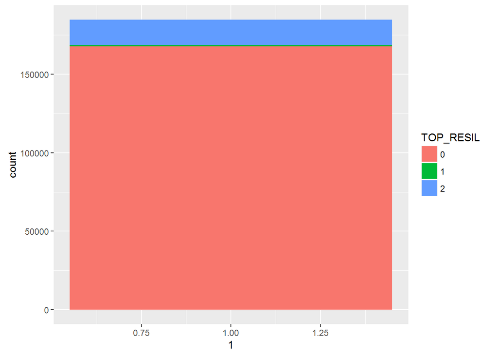

```r
ggplot(data=BASE,aes(x=1,fill=TOP_RESIL))+geom_bar()
```

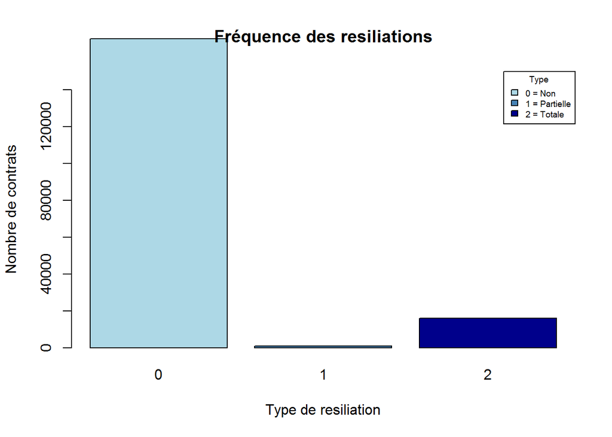

```r
barplot(table(BASE$TOP_RESIL),
        main= 'Fréquence des resiliations',
        col= c("lightblue","steelblue","darkblue"),
        legend.text =c("0 = Non","1 = Partielle","2 = Totale"),
        xlab="Type de resiliation", ylab="Nombre de contrats",
        ylim=c(0,150000),
        beside=TRUE,
        args.legend = list(x="topright",title= "Type", cex=0.6)
)
```

```r
# Note: hight imbalanced data set
```

More visualization

```r
table(BASE$ENT_TYPGRPE)
```

```
##
##    GRAND GROUPE GROUPE REGIONAL     HORS GROUPE
##            5299            4135          175218
```

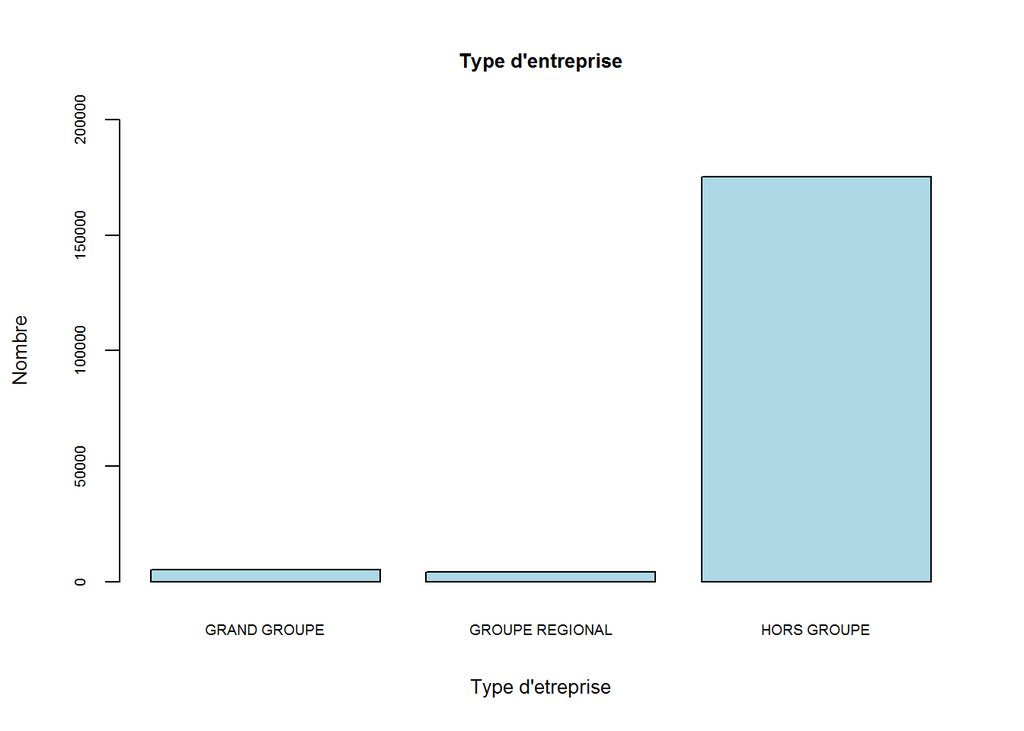

```r
barplot( table(BASE$ENT_TYPGRPE),col="lightblue",
         main="Type d'entreprise",
         xlab="Type d'etreprise", ylab="Nombre",
         cex.main=0.8, cex.axis=0.6,
         cex.names = 0.6, cex.lab=0.8, ylim= c(0,200000))
```

Client type vs. Target

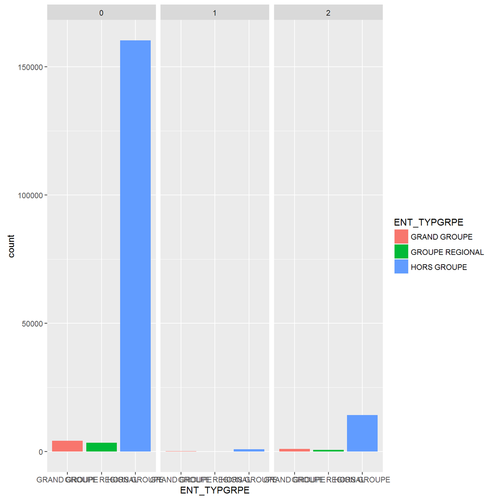

```r
ggplot(data = mutate(BASE,Tresil= as.factor(BASE$TOP_RESIL)),aes(x = ENT_TYPGRPE, fill = ENT_TYPGRPE)) + geom_bar() + facet_wrap(~ Tresil)
```

```r
# show the relation between the target and this feature
library(gmodels)
tbcgr<- CrossTable(BASE$TOP_RESIL,BASE$ENT_TYPGRPE,prop.r = FALSE)
```

```
##
##
##    Cell Contents
## |-------------------------|
## |                       N |
## | Chi-square contribution |
## |           N / Col Total |
## |         N / Table Total |
## |-------------------------|
##
##
## Total Observations in Table:  184652
##
##
##                | BASE$ENT_TYPGRPE
## BASE$TOP_RESIL |    GRAND GROUPE | GROUPE REGIONAL |     HORS GROUPE |       Row Total |
## ---------------|-----------------|-----------------|-----------------|-----------------|
##              0 |            4179 |            3382 |          160179 |          167740 |
##                |          83.680 |          37.294 |           6.396 |                 |
##                |           0.789 |           0.818 |           0.914 |                 |
##                |           0.023 |           0.018 |           0.867 |                 |
## ---------------|-----------------|-----------------|-----------------|-----------------|
##              1 |              82 |              68 |             845 |             995 |
##                |         100.040 |          93.808 |          10.415 |                 |
##                |           0.015 |           0.016 |           0.005 |                 |
##                |           0.000 |           0.000 |           0.005 |                 |
## ---------------|-----------------|-----------------|-----------------|-----------------|
##              2 |            1038 |             685 |           14194 |           15917 |
##                |         739.587 |         302.869 |          54.802 |                 |
##                |           0.196 |           0.166 |           0.081 |                 |
##                |           0.006 |           0.004 |           0.077 |                 |
## ---------------|-----------------|-----------------|-----------------|-----------------|
##   Column Total |            5299 |            4135 |          175218 |          184652 |
##                |           0.029 |           0.022 |           0.949 |                 |
## ---------------|-----------------|-----------------|-----------------|-----------------|
##
##
```

Show the distribution & skewed of some numeric features

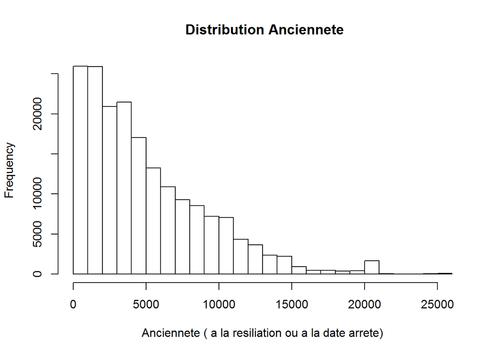

```r
# Histogram: company lifetime
hist(BASE$ENT_ANCIENNETE,xlab = 'Anciennete ( a la resiliation ou a la date arrete)', main = ' Distribution Anciennete')
```

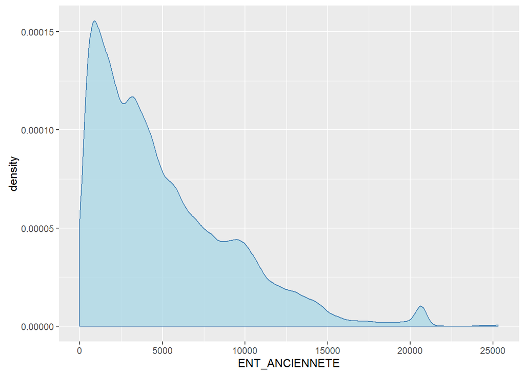

```r
# company lifetime density
ggplot(BASE,aes(x=ENT_ANCIENNETE))+
  geom_density(colour='steelblue',
               fill="lightblue",alpha=0.8)+
  expand_limits(x=0,y=0)
```

Visualizing the relation between this variable and the target

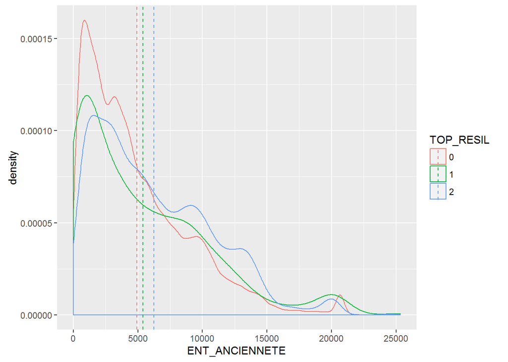

```r
#by density courbes
tm <- ddply(BASE, "TOP_RESIL", summarise, grp.mean=mean(ENT_ANCIENNETE))
ggplot(BASE,aes(x=ENT_ANCIENNETE))+
      geom_density(aes(group=TOP_RESIL, colour=TOP_RESIL, fill=NULL), alpha=0.6)+
      geom_vline(data=tm, aes(xintercept=grp.mean, color=TOP_RESIL),linetype="dashed")
```

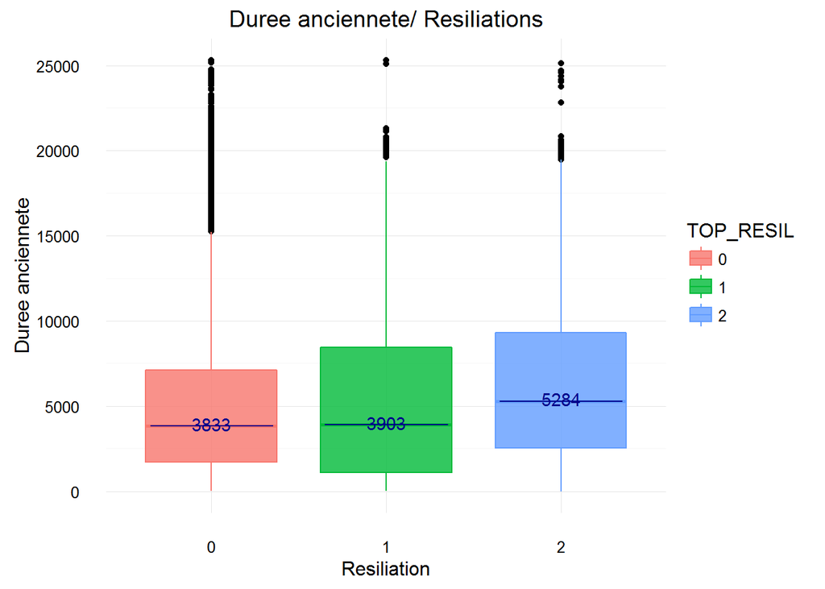

```r
# by box plots
theme<-theme_set(theme_minimal())
ggplot(BASE,
       mapping=aes_string(y="ENT_ANCIENNETE", x="TOP_RESIL"))+
  xlab("Resiliation")+
  ylab("Duree anciennete")+
  ggtitle("Duree anciennete/ Resiliations")+
  geom_boxplot(outlier.color = "black",
               aes_string(colour="TOP_RESIL",fill="TOP_RESIL"), alpha=0.8)+
  stat_summary(geom = "crossbar",
               width=0.7,
               fatten=0.5,
               color="darkblue",
               fun.data= function(x){
                 return(c(y=median(x),
                          ymin=median(x),
                          ymax=median(x)))
               })+ stat_summary(fun.data=function(x){
                 return(c(y=median(x)*1.03,
                          label= round(median(x),2)))
               }, geom = "text",
               fun.y= mean,
               colour= "darkblue")
```

More visualization

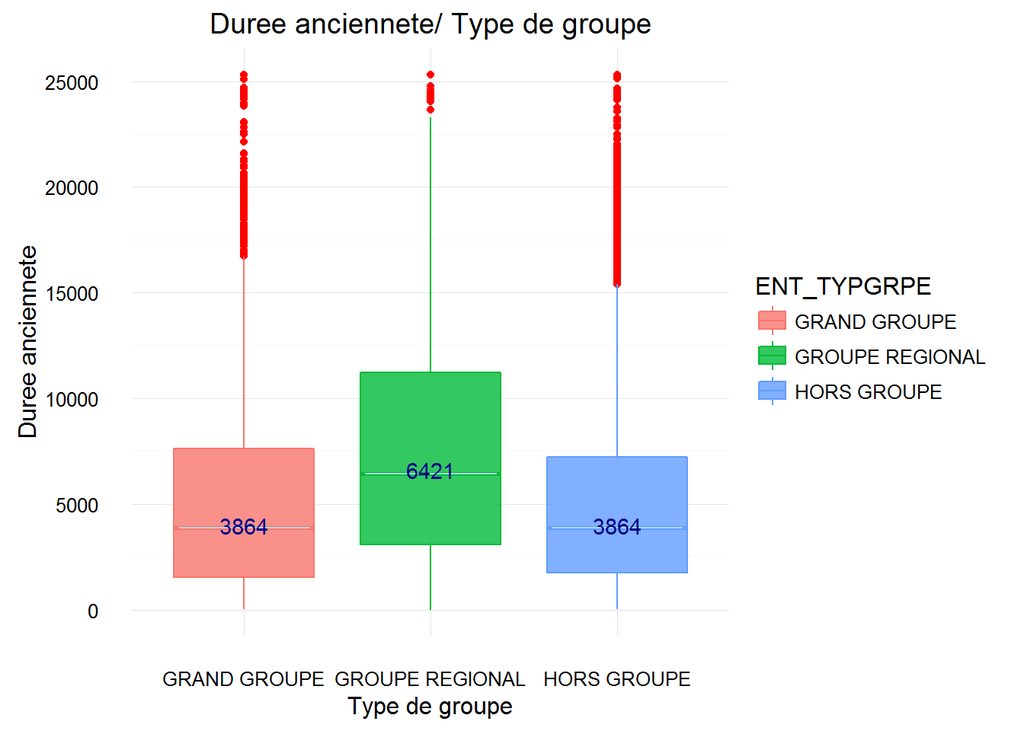

```r
# box plot: Anciennete/ Type client
ggplot(BASE,
       mapping=aes_string(y="ENT_ANCIENNETE", x="ENT_TYPGRPE"))+
  xlab("Type de groupe")+
  ylab("Duree anciennete")+
  ggtitle("Duree anciennete/ Type de groupe")+
  geom_boxplot(outlier.color = "red",
               aes_string(colour="ENT_TYPGRPE",fill="ENT_TYPGRPE"), alpha=0.8)+
  stat_summary(geom = "crossbar",
               width=0.7,
               fatten=0.5,
               color="lightblue",
               fun.data= function(x){
                 return(c(y=median(x),
                          ymin=median(x),
                          ymax=median(x)))
               })+ stat_summary(fun.data=function(x){
                 return(c(y=median(x)*1.03,
                          label= round(median(x),2)))
               }, geom = "text",
               fun.y= mean,
               colour= "darkblue")
```

```r
# Box plot : Directions ( from 1 to 9)/ Anciennete
group_by(BASE,ENT_DR)%>%
  summarise(anciennete_moyenne= mean( ENT_ANCIENNETE,na.rm=TRUE),
            anciennete_median=median( ENT_ANCIENNETE,na.rm = TRUE))
```

```
## # A tibble: 9 x 3
##   ENT_DR anciennete_moyenne anciennete_median
##   <fctr>              <dbl>             <dbl>
## 1      1           5298.264            4229.0
## 2      2           4790.930            3560.0
## 3      3           5369.490            4198.0
## 4      4           4507.050            3468.0
## 5      5           5521.657            4321.0
## 6      6           5265.156            4262.5
## 7      7           4489.769            2921.0
## 8      8           4818.025            3639.5
## 9      9           5077.488            4048.0
```

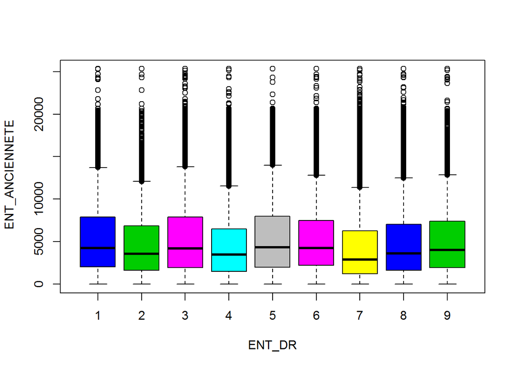

```r
boxplot(ENT_ANCIENNETE ~ ENT_DR,BASE, range=1, xlab= 'ENT_DR',ylab= ' ENT_ANCIENNETE',col=c('116','99','102','53','424','214','135'))
```

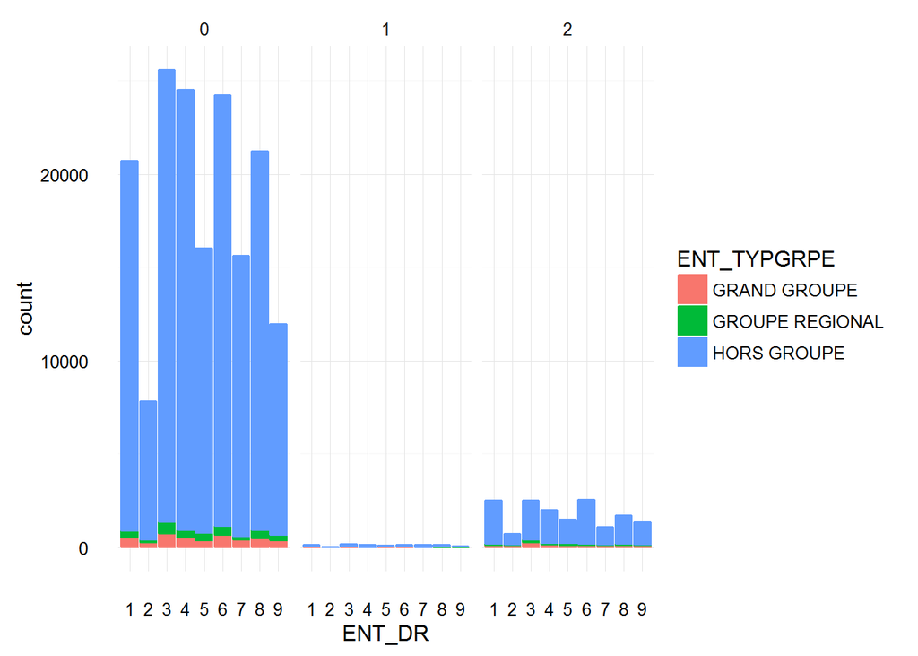

```r
# Target/ Directions
ggplot(BASE, aes(x=ENT_DR, fill = ENT_TYPGRPE)) + geom_bar(aes(colour = ENT_TYPGRPE))+ facet_wrap(~ TOP_RESIL)
```

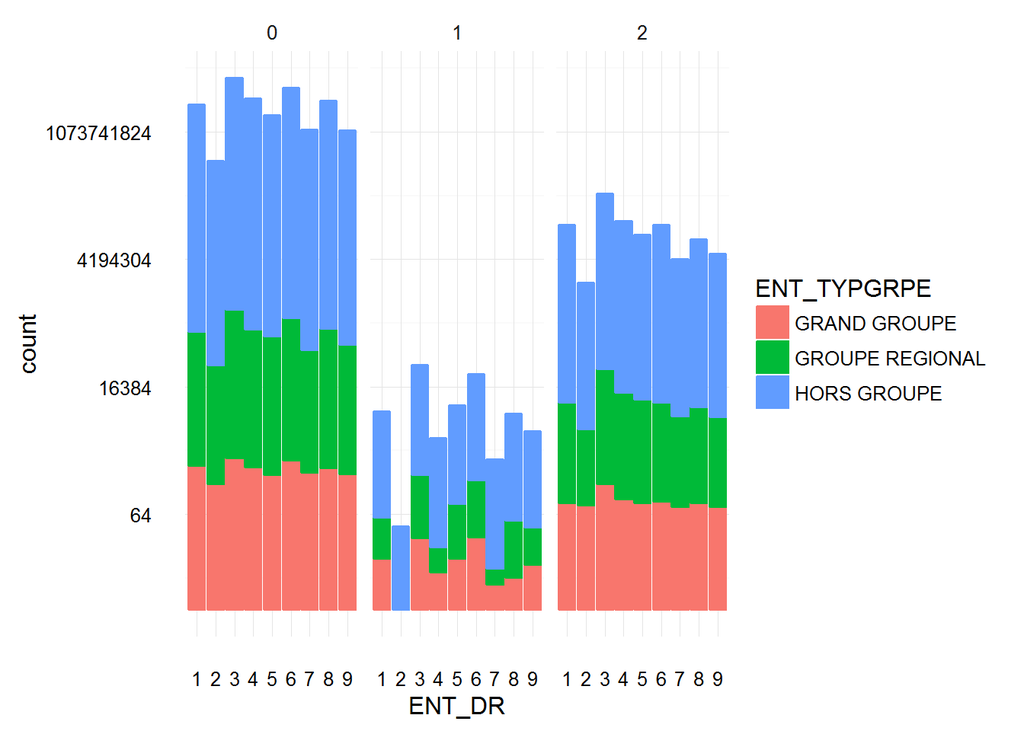

```r
ggplot(BASE, aes(x=ENT_DR, fill = ENT_TYPGRPE)) + geom_bar(aes(colour = ENT_TYPGRPE))+ facet_wrap(~ TOP_RESIL)+ scale_y_continuous(trans='log2')
```

Check variables concerning Employee’s age

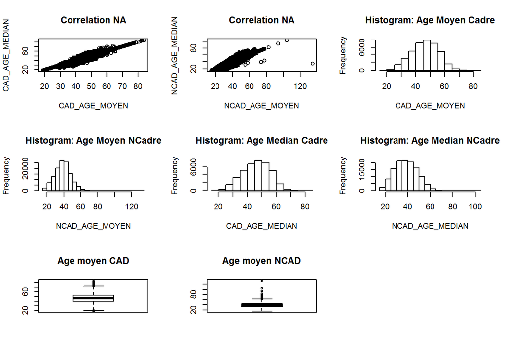

```r
# correlation : CAD Age Moyen vs Median et NCAD Age Moyen vs Median
library(UsingR)
attach(BASE)
par(mfrow=c(3,3))
plot(CAD_AGE_MOYEN,CAD_AGE_MEDIAN, main=paste("Correlation",signif(cor(CAD_AGE_MOYEN,CAD_AGE_MEDIAN),2)))
plot(NCAD_AGE_MOYEN,NCAD_AGE_MEDIAN, main=paste("Correlation",signif(cor(NCAD_AGE_MOYEN,NCAD_AGE_MEDIAN),2)))
hist(CAD_AGE_MOYEN, main="Histogram: Age Moyen Cadre")
hist(NCAD_AGE_MOYEN,main="Histogram: Age Moyen NCadre")
hist(CAD_AGE_MEDIAN, main="Histogram: Age Median Cadre")
hist(NCAD_AGE_MEDIAN,main="Histogram: Age Median NCadre")
# box plots
boxplot(CAD_AGE_MOYEN, main="Age moyen CAD")
boxplot(NCAD_AGE_MOYEN, main="Age moyen NCAD")
```

Check more variables

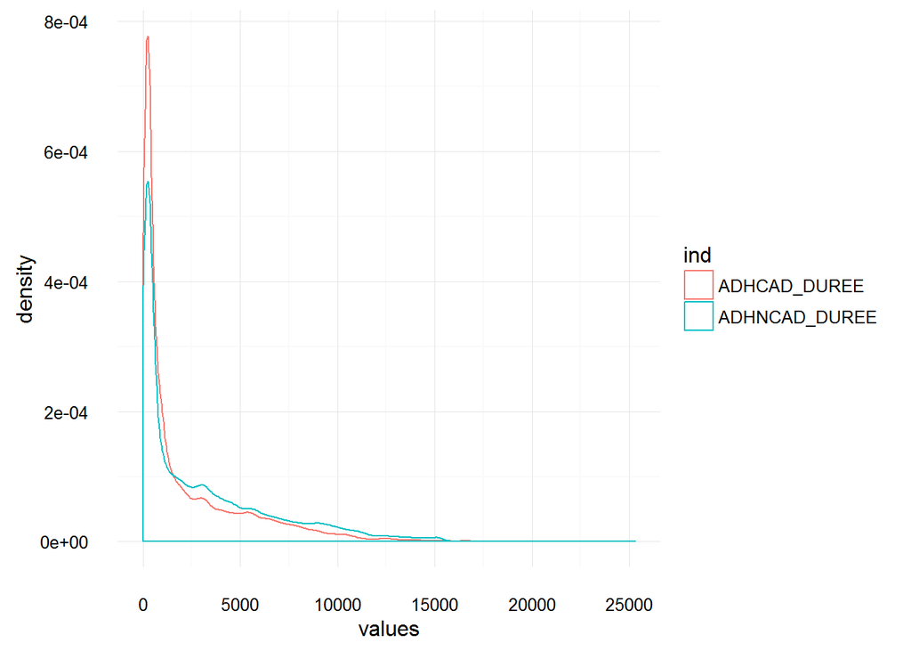

```r
# Contract lifetime for 2 types of contract: Cadre & Non Cadre
ddf<-subset(BASE,select = c("ADHCAD_DUREE","ADHNCAD_DUREE"))
ddf<-stack(ddf)# mettre les noms des colonnes en colonnes.
ggplot(ddf,aes(x=values))+geom_density(aes(group=ind,colour=ind))
```

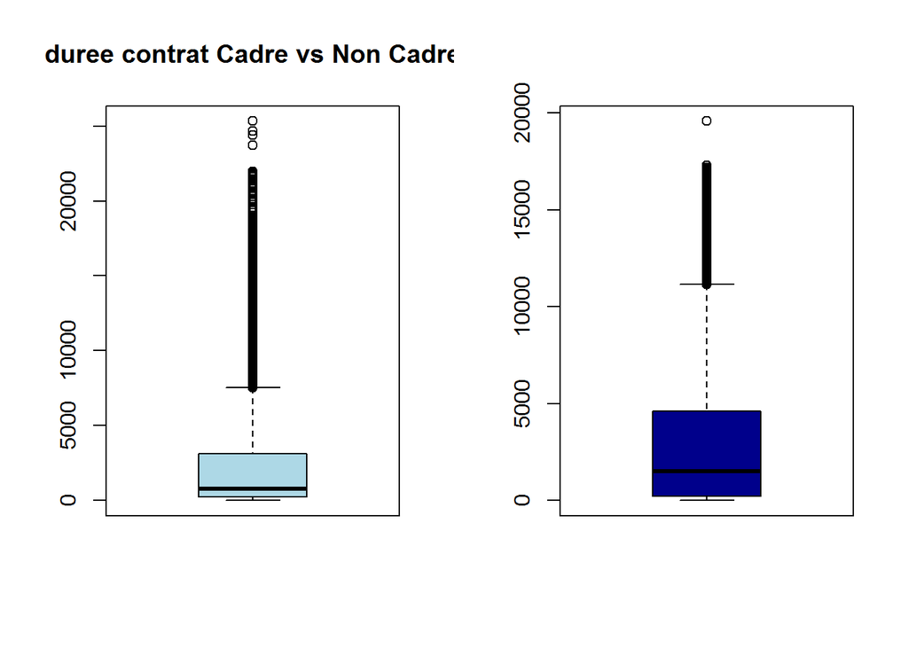

```r
# box  plots
par(mfrow=c(1,2))
boxplot(BASE$ADHCAD_DUREE,col = "lightblue",main= "duree contrat Cadre vs Non Cadre")
boxplot(BASE$ADHNCAD_DUREE,col = "darkblue")
```

# Feature Engineering- 1st attempt

Remove the variables having many Na’s values or very high correlation. We will work also with the variables grouping 2 notions: Cadre & Non Cadre

```r
myvars<- names(BASE) %in% c("DTARRETE","MIN_DTRESIL","ENT_ACMAIL", "INT_ETATABO","ADHCAD_OFC_ANNEEEFFET",
                          "MUNASAF_AGEMOYEN","MUNASAF_TOPADHFM","MUNASAF_TOPADHPRVRTA","MUNASAF_TOPADHIND","MUNASAF_MAXNBCTADINA",
                            "MUNASAF_MINDELAICTADINA","ADHCAD_TOPRESIL","ADHCAD_DUREE","ADHCAD_TYPCT","ADHCAD_GAMMEERP","ADHCAD_FORMULE",
                            "ADHCAD_TARIF","ADHCAD_OPTSHPO","ADHCAD_OFC", "ADHNCAD_DUREE","ADHNCAD_TYPCT","ADHNCAD_GAMMEERP",
                            "ADHNCAD_FORMULE","ADHNCAD_TARIF","ADHNCAD_OPTSHPO","ADHNCAD_OFC", "ADHNCAD_TOPRESIL",
                            "ADHCAD_OFC_ANNEEEFFET","ADHNCAD_OFC_ANNEEEFFET",
                            'AFFCAD_NBSAL', 'AFFCAD_FM_NBSAL', 'AFFCAD_FM_TAUXSAL', 'CAD_ADIFUE',
                            'CAD_AGE_MOYEN', 'CAD_AGE_MEDIAN','AFFCAD_FM_N1_NBSAL','AFFCAD_FM_N2_NBSAL','AFFCAD_FM_N3_NBSAL',
                            'AFFNCAD_NBSAL', 'AFFNCAD_FM_NBSAL', 'AFFNCAD_FM_TAUXSAL', 'NCAD_ADIFUE',
                            'NCAD_AGE_MOYEN', 'NCAD_AGE_MEDIAN','AFFNCAD_FM_N1_NBSAL','AFFNCAD_FM_N2_NBSAL','AFFNCAD_FM_N3_NBSAL',
                            "BASEDMC_ANNEE_RESIL","BASEDMC_DATE_SAISIE","BASEDMC_RESIL_FMO","BASEDMC_RESIL_FME",
                            "BASEDMC_RESIL_FMC","TER_DR","TER_DDSECT","CTAD_DELAI_FM","CTCO_DELAI_FM","CTAD_DELAI_HORSFM",
                            "CTCO_DELAI_HORSFM","CTAD_DELAI_INA", "CTAD_DELAI_INAFM","CTUAD_NBCAD_INA","CTUAD_NBNCAD_INA",
                           "CTCO_DELAI_VISITE","CTCO_DELAI_SIM","CTAD_DELAI_TELENTRANT","CTAD_DELAI_TELSORTANT","CTCO_DELAI_TELENTRANT",
                           "CTCO_DELAI_TELSORTANT","TER_CASECT",'TER_DELE')
dat<-BASE[!myvars]
dim(dat)#[1] 184652 71: new data set
```

```
## [1] 184652     71
```

```r
df_status(dat)
```

```
##                       variable q_zeros p_zeros  q_na  p_na q_inf p_inf
## 1                      MUNAENT       0    0.00     0  0.00     0     0
## 2                    TOP_RESIL  167740   90.84     0  0.00     0     0
## 3                  ENT_TYPGRPE       0    0.00     0  0.00     0     0
## 4                       ENT_DR       0    0.00     0  0.00     0     0
## 5                     ENT_DEPT       0    0.00     0  0.00     0     0
## 6               ENT_ANCIENNETE       0    0.00     0  0.00     0     0
## 7                     ENT_NACE       0    0.00     0  0.00     0     0
## 8                   ENT_APENAF       0    0.00     0  0.00     0     0
## 9                   ENT_CATJUR       0    0.00     0  0.00     0     0
## 10                  ENT_TOPTEL   15131    8.19     0  0.00     0     0
## 11              ENT_TOPTELPORT   78882   42.72     0  0.00     0     0
## 12                 ENT_TOPMAIL   37183   20.14     0  0.00     0     0
## 13                   INT_DTABO       0    0.00     0  0.00     0     0
## 14                    ENT_CHEF  115899   62.77     0  0.00     0     0
```

[output cut: 129 more lines]

```r
# let's impute median value to Age_Moyen variable ( 52028 missing values)
dat$AGE_MOYEN[is.na(dat$AGE_MOYEN)]<- median(dat$AGE_MOYEN,na.rm = TRUE)
# retirer N° ID
dat1<-dat[-1]# / [1] 184652     70
```

Split again the new data set

```r
splitclass1<- split(names(dat1), sapply(dat1, function(x){class(x)}))
splitclass1
```

```
## $factor
##  [1] "TOP_RESIL"                   "ENT_TYPGRPE"
##  [3] "ENT_DR"                      "ENT_DEPT"
##  [5] "ENT_NACE"                    "ENT_APENAF"
##  [7] "ENT_CATJUR"                  "ENT_TOPTEL"
##  [9] "ENT_TOPTELPORT"              "ENT_TOPMAIL"
## [11] "INT_DTABO"                   "ENT_CHEF"
## [13] "ENT_CREATEUR"                "TIERS_TOPCPT"
## [15] "MUNASAF_NBPA"                "MUNASAF_TOPPRESENCE"
## [17] "ADHENT_RET"                  "ADHENT_GAT"
## [19] "ADHENT_PRV"                  "ADHENT_PVS"
## [21] "ADHENT_GDIA"                 "ADHENT_RCJ"
## [23] "ADHENT_PPAB"                 "ADHENT_EPS"
## [25] "CONC_FM"                     "CTX_TOPLJ"
## [27] "CTX_TOPRJ"                   "BASEDMC_TYPERESIL"
```

[output cut: 19 more lines]

```r
# extracting numeric vaiables
varnum1<-dat1[splitclass1$numeric]
#correlations
cor_var<- cor(varnum1)
head(cor_var,5)
```

```
##                ENT_ANCIENNETE  CTAD_NB_FM  CTCO_NB_FM CTAD_NB_HORSFM
## ENT_ANCIENNETE     1.00000000 -0.01837687 -0.03362992     0.02400576
## CTAD_NB_FM        -0.01837687  1.00000000  0.54576982     0.44940537
## CTCO_NB_FM        -0.03362992  0.54576982  1.00000000     0.39334800
## CTAD_NB_HORSFM     0.02400576  0.44940537  0.39334800     1.00000000
## CTCO_NB_HORSFM    -0.02509860  0.43010571  0.49943266     0.51690105
##                CTCO_NB_HORSFM CTAD_NB_INA CTAD_NB_INAFM CTCO_NB_VISITE
## ENT_ANCIENNETE     -0.0250986  0.04270025   0.004812260    -0.03534467
## CTAD_NB_FM          0.4301057  0.08353448   0.121729130     0.12452489
## CTCO_NB_FM          0.4994327  0.02686128   0.037232112     0.18187934
## CTAD_NB_HORSFM      0.5169010  0.09778251   0.025232635     0.08459154
## CTCO_NB_HORSFM      1.0000000  0.01829932   0.005954394     0.18552467
##                CTCO_NB_SIM CTAD_NB_TELENTRANT CTAD_NB_TELSORTANT
## ENT_ANCIENNETE  -0.0422348         0.03633654       -0.008627555
## CTAD_NB_FM       0.4324031         0.20483028        0.108657085
## CTCO_NB_FM       0.7189753         0.09396540        0.082859131
## CTAD_NB_HORSFM   0.3007441         0.25328489        0.058732642
## CTCO_NB_HORSFM   0.4378078         0.10638956        0.051927258
##                CTCO_NB_TELENTRANT CTCO_NB_TELSORTANT    PRESTFM_N
## ENT_ANCIENNETE        -0.07494401        -0.04569379  0.099197845
## CTAD_NB_FM             0.14644388         0.14276960 -0.009233709
## CTCO_NB_FM             0.17926587         0.26689698 -0.018036726
## CTAD_NB_HORSFM         0.11594094         0.07815866  0.007800188
## CTCO_NB_HORSFM         0.13667580         0.23015351 -0.012806725
##                 PRESTFM_N_1  PRESTFM_N_2  PRESTFM_N_3      CGAFM_N
## ENT_ANCIENNETE  0.103110138  0.108757552  0.123490449  0.078320661
## CTAD_NB_FM     -0.012262992 -0.012575972 -0.014095185 -0.007778472
## CTCO_NB_FM     -0.020495653 -0.020541578 -0.022807634 -0.014074778
## CTAD_NB_HORSFM  0.006594938  0.005219821  0.004448136  0.003599022
## CTCO_NB_HORSFM -0.013940815 -0.015231447 -0.017830525 -0.009432216
##                   CGAFM_N_1    CGAFM_N_2    CGAFM_N_3   AGE_MOYEN
## ENT_ANCIENNETE  0.083835693  0.092157587  0.100144165  0.14773475
## CTAD_NB_FM     -0.009279845 -0.009722412 -0.010731542 -0.07638667
## CTCO_NB_FM     -0.015689577 -0.016526611 -0.017824205 -0.08867748
## CTAD_NB_HORSFM  0.003719413  0.004606423  0.004479078 -0.04913223
## CTCO_NB_HORSFM -0.010681008 -0.011892967 -0.013184837 -0.09217451
##                  ADH_DUREE    AFF_NBSAL AFF_FM_NBSAL AFF_FM_TAUXSAL
## ENT_ANCIENNETE  0.69764851  0.109189159  0.101913283    -0.01978661
## CTAD_NB_FM     -0.07889151 -0.003741307 -0.004936117     0.05163638
## CTCO_NB_FM     -0.11722109 -0.016223922 -0.016508611     0.04301387
## CTAD_NB_HORSFM  0.02672102  0.008590809  0.010985518     0.11325959
## CTCO_NB_HORSFM -0.04164592 -0.016780314 -0.013425720     0.10675250
##                   AFF_FM_N1    AFF_FM_N2   AFF_FM_N3
## ENT_ANCIENNETE  0.111458201  0.119806134  0.15351072
## CTAD_NB_FM     -0.012434027 -0.013552774 -0.01538673
## CTCO_NB_FM     -0.023761935 -0.023992037 -0.02838338
## CTAD_NB_HORSFM  0.008979744  0.008620263  0.01680708
## CTCO_NB_HORSFM -0.015242070 -0.015922175 -0.01652937
```

```r
varnum2<-subset(dat1, select = c('TOP_RESIL',splitclass1$numeric))# numeric variables with the target
dim(varnum2)
```

```
## [1] 184652     30
```

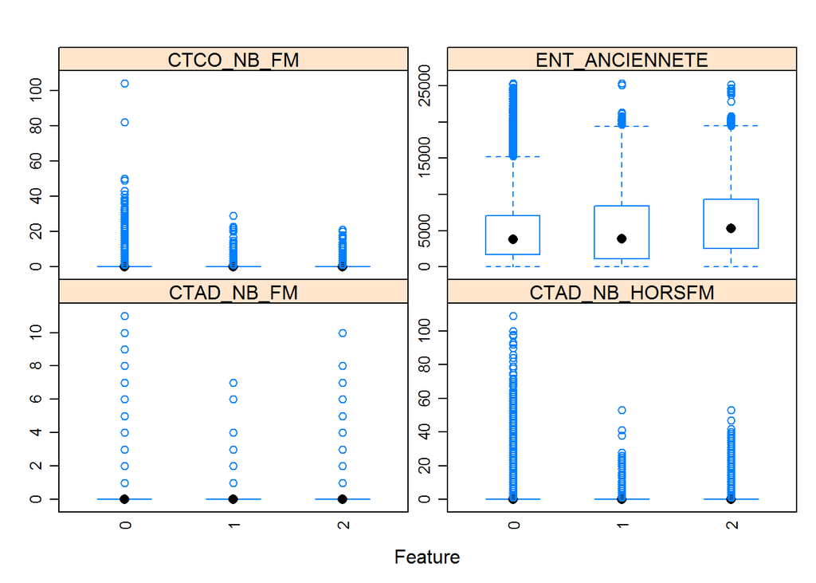

```r
# check some features by visualization
featurePlot(x = varnum2[2:5],
            y = varnum2$TOP_RESIL,
            plot = "box",
            scales = list(y = list(relation="free"),
            x = list(rot = 90)),
            layout = c(2,2),
            auto.key = list(columns = 2))
```

**Preparing data set for Machine Learning implementation/ Train & Test sets**

define an 70% train/30% test by splitting the dataset

```r
split=0.7
trainIndex <- createDataPartition(dat1$TOP_RESIL, p=split, list=FALSE)
data_train <- dat1[ trainIndex,]
data_test <- dat1[-trainIndex,]
# check
dim(data_train)
```

```
## [1] 129257     70
```

```r
dim(data_test)
```

```
## [1] 55395    70
```

```r
table(data_train$TOP_RESIL)
```

```
##
##      0      1      2
## 117418    697  11142
```

```r
table(data_test$TOP_RESIL)
```

```
##
##     0     1     2
## 50322   298  4775
```

# Machine Learning

Since there is an outcome to predict for our models, supervised methods will be applied.

I start applying different ML algorithms ( Naives Bayes, Random Forest, Tree Decisions, Multinomial Logistic and Linear Discriminant Analysis).For each one of them , I will try to run a model on the splitted data set and another one with K-fold Cross-validation ( repeated or not).

You will see that belong to the model applied, more feature engineering can be done.

Let’s get started

# Random Forest in the train set & test set

```r
# to remove variables having more than 53 levels- required by RF in R
myvars1<- names(data_train)%in% c('ENT_DEPT','ADH_OPTSHPO','BASEDMC_NOUVELASSUREUR','BASEDMC_MECONTENTEMENT','INT_DTABO','ENT_APENAF','ENT_NACE')

# create the train et set data for this model
data_trainRF<- data_train[!myvars1]
data_testRF<- data_test[!myvars1]
set.seed<-(2345)
modelRf<- randomForest(TOP_RESIL~., data=data_trainRF,ntree=350,na.action=na.omit)
modelRf
```

```
##
## Call:
##  randomForest(formula = TOP_RESIL ~ ., data = data_trainRF, ntree = 350,      na.action = na.omit)
##                Type of random forest: classification
##                      Number of trees: 350
## No. of variables tried at each split: 7
##
##         OOB estimate of  error rate: 4.32%
## Confusion matrix:
##        0  1    2 class.error
## 0 116868  3  547  0.00468412
## 1    488 70  139  0.89956958
## 2   4401  1 6740  0.39508167
```

make prediction & check model accuracy

```r
# make prediction
predictionsRf<- predict(modelRf,data_testRF[,2:63])
confusionMatrix(predictionsRf, data_testRF[,1])# not too bad as score (accuracy= 96%)
```

```
## Confusion Matrix and Statistics
##
##           Reference
## Prediction     0     1     2
##          0 50124   219  1881
##          1     0    23     0
##          2   198    56  2894
##
## Overall Statistics
##
##                Accuracy : 0.9575
##                  95% CI : (0.9558, 0.9592)
##     No Information Rate : 0.9084
##     P-Value [Acc > NIR] : < 2.2e-16
##
##                   Kappa : 0.6936
##  Mcnemar's Test P-Value : < 2.2e-16
##
## Statistics by Class:
##
##                      Class: 0  Class: 1 Class: 2
## Sensitivity            0.9961 0.0771812  0.60607
## Specificity            0.5860 1.0000000  0.99498
## Pos Pred Value         0.9598 1.0000000  0.91931
## Neg Pred Value         0.9376 0.9950336  0.96400
## Prevalence             0.9084 0.0053795  0.08620
## Detection Rate         0.9048 0.0004152  0.05224
## Detection Prevalence   0.9428 0.0004152  0.05683
## Balanced Accuracy      0.7911 0.5385906  0.80053
```

see feature importance

```r
#see feature importance
varImpRF<-varImp(modelRf)
varImpRF$variables<-row.names(varImpRF)
varImpRF<-varImpRF[order(-varImpRF$Overall),]
varImpRF
```

```
##                                 Overall                   variables
## ADH_DUREE                   1601.110653                   ADH_DUREE
## PRESTFM_N                    915.402522                   PRESTFM_N
## ENT_ANCIENNETE               787.142474              ENT_ANCIENNETE
## CGAFM_N_1                    721.250684                   CGAFM_N_1
## AFF_FM_N1                    713.395014                   AFF_FM_N1
## CGAFM_N                      712.682611                     CGAFM_N
## AFF_FM_N2                    690.401576                   AFF_FM_N2
## BASEDMC_TYPERESIL            640.613482           BASEDMC_TYPERESIL
## ADH_TARIF                    602.124156                   ADH_TARIF
## BASEDMC_RESIL_MOTIF          601.101886         BASEDMC_RESIL_MOTIF
## ENT_CATJUR                   563.718593                  ENT_CATJUR
## ENT_DR                       517.162102                      ENT_DR
## PRESTFM_N_3                  515.916633                 PRESTFM_N_3
## CTX_TOPLJ                    510.031445                   CTX_TOPLJ
## ADH_FORMULE                  505.111451                 ADH_FORMULE
## AFF_NBSAL                    499.707806                   AFF_NBSAL
## PRESTFM_N_1                  495.644880                 PRESTFM_N_1
## AFF_FM_N3                    492.927134                   AFF_FM_N3
## CGAFM_N_2                    474.887690                   CGAFM_N_2
## BASEDMC_SOUSCCONCURRENCE     473.480283    BASEDMC_SOUSCCONCURRENCE
## CGAFM_N_3                    458.326550                   CGAFM_N_3
## AFF_FM_TAUXSAL               425.364725              AFF_FM_TAUXSAL
## ADH_OFC                      422.674076                     ADH_OFC
## AFF_FM_NBSAL                 377.707763                AFF_FM_NBSAL
## PRESTFM_N_2                  364.464399                 PRESTFM_N_2
## TIERS_TOPCPT                 268.681552                TIERS_TOPCPT
## CTCO_NB_TELSORTANT           238.990443          CTCO_NB_TELSORTANT
## ENT_TOPMAIL                  232.776468                 ENT_TOPMAIL
## CTAD_NB_TELENTRANT           227.787470          CTAD_NB_TELENTRANT
## BASEDMC_MOTIVATIONORGANISME  208.608714 BASEDMC_MOTIVATIONORGANISME
## AGE_MOYEN                    164.822170                   AGE_MOYEN
## CTCO_NB_HORSFM               152.720437              CTCO_NB_HORSFM
## BASEDMC_CHOIXMOTIVORGA       151.301227      BASEDMC_CHOIXMOTIVORGA
## ADH_TYPCT                    150.826573                   ADH_TYPCT
## ENT_CHEF                     149.185705                    ENT_CHEF
## ADHENT_GAT                   137.914785                  ADHENT_GAT
## ADHENT_PPAB                  125.573766                 ADHENT_PPAB
## CTAD_NB_HORSFM               124.043295              CTAD_NB_HORSFM
## ENT_TYPGRPE                   98.882867                 ENT_TYPGRPE
```

[output cut: 8 more lines]

```
## CTCO_NB_TELENTRANT            58.830978          CTCO_NB_TELENTRANT
## ADHENT_RET                    56.445283                  ADHENT_RET
## CTX_TOPRJ                     53.500472                   CTX_TOPRJ
## ADHENT_RCJ                    49.238617                  ADHENT_RCJ
## MUNASAF_TOPPRESENCE           49.163742         MUNASAF_TOPPRESENCE
## CTAD_NB_INA                   40.877703                 CTAD_NB_INA
## CTAD_NB_TELSORTANT            38.660639          CTAD_NB_TELSORTANT
## CTCO_NB_FM                    38.305377                  CTCO_NB_FM
## CTAD_NB_INAFM                 23.993263               CTAD_NB_INAFM
## CTAD_NB_FM                    22.848812                  CTAD_NB_FM
## ADHENT_EPS                    18.584487                  ADHENT_EPS
## CTCO_NB_SIM                   13.029946                 CTCO_NB_SIM
## ENT_CREATEUR                  12.270350                ENT_CREATEUR
## ADIFUE                         9.771839                      ADIFUE
## CONC_FM                        4.049116                     CONC_FM
```

let’s make a plot of feature importance and check error with the best number oftrees

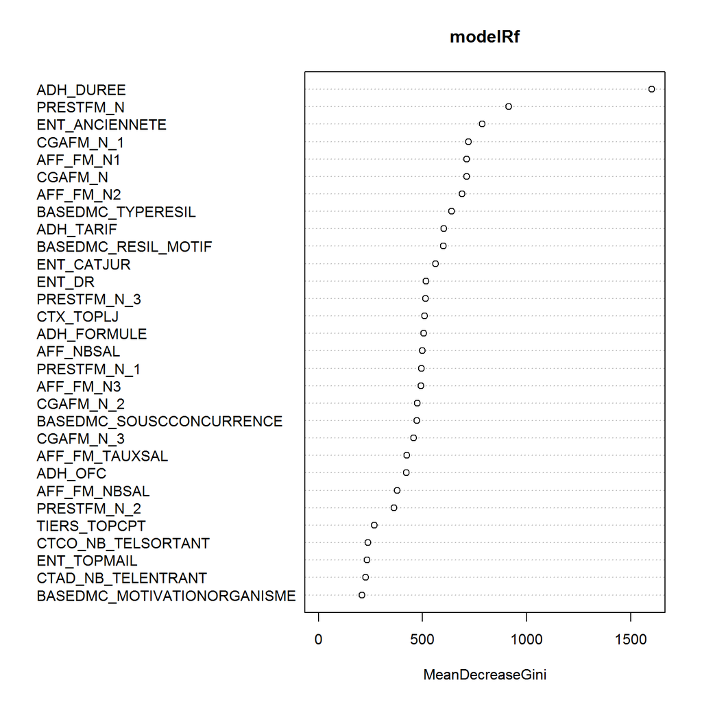

```r
#plot Feature importance
varImpPlot(modelRf,type = 2)# remember that we will use this result for Multinomial Logistic&Tree decision)
```